# Final Project

Sid Pothuganti, Sohini Roy, Annmay Sharma

2023-04-27

# **Project Question**

The data set we have chosen shows us an overview of the different prices of Airbnbs in European cities. There are 20 different provided variables, such as the type of room (room_type), capacity (person_capacity), whether or not the host is a superhost (host_is_superhost), and more. Based on this data, we would like to conduct a thorough analysis of which of the 19 other predictors contributes the most significantly to the guest’s overall satisfaction rating at the end of their stay (guest_satisfaction_overall). This could be useful to find what factors truly affect guest satisfaction and what might be unnecessary. This will be a regression analysis to determine what is the best model using the statistically significant predictors to predict the guest’s overall satisfaction rating.

# **Literature Review**

The NIH (specifically the National Center for Biotechnology Information) did a study exploring the sources of satisfaction and dissatisfaction in Airbnb accommodation by analyzing online reviews on the app. The results tell Airbnb hosts which aspects of the listing to focus on improving and which ones are not as important, and how to avoid dissatisfaction of guests as well as create satisfaction. Some of the results include maintaining boundaries between “private” and “shared” room rentals to avoid guest conflicts, providing training to hosts to know the proper way of communicating with users, as well as maintaining the cleanliness and hygiene basics expected by every guest. The methodologies used in this study include an emphasis on more computational linguistic-based approaches, for instance sentiment analysis and topic modeling. Within the sDLA analysis statistical summary, we are able to see the p-values in accordance with the topics so we can see which variables are significant, like we did with ours. (source: https://www.ncbi.nlm.nih.gov/pmc/articles/PMC8096999/)

Another study was done by Corvinus University in Hungary that analyzed Airbnb customer reviews in a similar fashion, to explore the factors that contributed to user ratings the most heavily. The dataset was inclusive of customer ratings, reviews, and information about the rooms. Two of the main methods of analysis used here were TF-IDF (term frequency- inverse document frequency) and lasso-based feature selection. With the lasso-based feature selection, a listing is determined to be “positive” or “negative” depending on whether the rating is above the upper docile or below the bottom docile, respectively. In order to carry this out, random samples are generated from the reviews, are divided into training/testing sets, and then the comment is categorized. The results of this study showed that there was a positive bias towards the hosts in the comments, and that the two most important factors in customer satisfaction were “location” and “cleanliness”. With customer dissatisfaction however, it seemed that “location”, “amenities”, and “price” were key determinants. (source: https://marcellgranat.github.io/airbnb-research/index.html).

# **Data**

In order to analyze our topic, we used a dataset on Kaggle that provided a variety of information on AirBnB listings in different cities in Europe. We chose to analyze the London weekends dataset, simply because it was the largest dataset, and had the most data available to build better models.

# **Empirical Application**

In order to analyze our data, we used multiple approaches to find the most accurate model; linear regression, stepwise selection, and decision trees.

Loading in packages

```r
library(MASS)
library(caret)
library(ISLR2)
library(tree)
library(dplyr)
library(randomForest)
library(tibble)
```

Loading in our training data to variable “london_data”:

```r
london_data <- read.csv("london_weekends.csv") #reading in csv
london_data <- london_data[, c(-1)] #dropping first index column
```

Let us take a look at a quick summary of the remaining variables in our data.

```r
summary(london_data)
```

```
##     realSum          room_type         room_shared        room_private
##  Min.   :   54.33   Length:5379        Length:5379        Length:5379
##  1st Qu.:  174.51   Class :character   Class :character   Class :character
##  Median :  268.12   Mode  :character   Mode  :character   Mode  :character
##  Mean   :  364.39
##  3rd Qu.:  438.27
##  Max.   :12937.27
##  person_capacity host_is_superhost      multi             biz
##  Min.   :2.000   Length:5379        Min.   :0.0000   Min.   :0.0000
##  1st Qu.:2.000   Class :character   1st Qu.:0.0000   1st Qu.:0.0000
##  Median :2.000   Mode  :character   Median :0.0000   Median :0.0000
##  Mean   :2.858                      Mean   :0.2798   Mean   :0.3579
##  3rd Qu.:4.000                      3rd Qu.:1.0000   3rd Qu.:1.0000
##  Max.   :6.000                      Max.   :1.0000   Max.   :1.0000
##  cleanliness_rating guest_satisfaction_overall    bedrooms
##  Min.   : 2.000     Min.   : 20.00             Min.   :0.000
##  1st Qu.: 9.000     1st Qu.: 87.00             1st Qu.:1.000
##  Median :10.000     Median : 94.00             Median :1.000
##  Mean   : 9.194     Mean   : 90.92             Mean   :1.133
##  3rd Qu.:10.000     3rd Qu.: 99.00             3rd Qu.:1.000
##  Max.   :10.000     Max.   :100.00             Max.   :8.000
##       dist            metro_dist        attr_index      attr_index_norm
##  Min.   : 0.04056   Min.   :0.01388   Min.   :  68.74   Min.   :  4.778
##  1st Qu.: 3.54568   1st Qu.:0.32404   1st Qu.: 177.22   1st Qu.: 12.320
##  Median : 4.93914   Median :0.53613   Median : 247.65   Median : 17.215
##  Mean   : 5.32762   Mean   :1.01653   Mean   : 294.58   Mean   : 20.477
##  3rd Qu.: 6.83807   3rd Qu.:1.09076   3rd Qu.: 361.07   3rd Qu.: 25.099
##  Max.   :17.32120   Max.   :9.17409   Max.   :1438.56   Max.   :100.000
##    rest_index     rest_index_norm        lng                lat
##  Min.   : 140.5   Min.   :  2.515   Min.   :-0.25170   Min.   :51.41
##  1st Qu.: 382.1   1st Qu.:  6.839   1st Qu.:-0.16996   1st Qu.:51.49
##  Median : 527.3   Median :  9.439   Median :-0.11813   Median :51.51
##  Mean   : 625.6   Mean   : 11.197   Mean   :-0.11478   Mean   :51.50
##  3rd Qu.: 764.2   3rd Qu.: 13.678   3rd Qu.:-0.06772   3rd Qu.:51.53
##  Max.   :5587.1   Max.   :100.000   Max.   : 0.12018   Max.   :51.58
```

```r
# Linear regression line.
lm.fit <- lm(guest_satisfaction_overall~ ., data=london_data)
summary(lm.fit)
```

```
##
## Call:
## lm(formula = guest_satisfaction_overall ~ ., data = london_data)
##
## Residuals:
##     Min      1Q  Median      3Q     Max
## -78.038  -2.347   0.868   3.197  33.981
##
## Coefficients: (4 not defined because of singularities)
##                         Estimate Std. Error t value Pr(>|t|)
## (Intercept)           -4.738e+02  1.944e+02  -2.438   0.0148 *
## realSum                3.243e-04  2.615e-04   1.240   0.2150
## room_typePrivate room  1.483e+00  2.520e-01   5.887 4.17e-09 ***
## room_typeShared room   3.850e-01  1.406e+00   0.274   0.7843
## room_sharedTrue               NA         NA      NA       NA
## room_privateTrue              NA         NA      NA       NA
## person_capacity        1.087e-01  1.187e-01   0.915   0.3600
## host_is_superhostTrue  1.334e+00  2.765e-01   4.824 1.45e-06 ***
## multi                 -1.055e+00  2.526e-01  -4.178 2.99e-05 ***
## biz                   -3.910e+00  2.558e-01 -15.288  < 2e-16 ***
## cleanliness_rating     6.921e+00  8.963e-02  77.218  < 2e-16 ***
## bedrooms               4.400e-01  2.217e-01   1.984   0.0473 *
## dist                  -4.894e-02  8.234e-02  -0.594   0.5523
## metro_dist             2.787e-01  1.290e-01   2.160   0.0308 *
## attr_index            -5.360e-04  1.620e-03  -0.331   0.7408
## attr_index_norm               NA         NA      NA       NA
## rest_index             3.463e-04  6.124e-04   0.565   0.5718
## rest_index_norm               NA         NA      NA       NA
## lng                   -5.922e-01  1.957e+00  -0.303   0.7622
## lat                    9.721e+00  3.768e+00   2.580   0.0099 **
## ---
## Signif. codes:  0 '***' 0.001 '**' 0.01 '*' 0.05 '.' 0.1 ' ' 1
##
## Residual standard error: 7.232 on 5363 degrees of freedom
## Multiple R-squared:  0.5908, Adjusted R-squared:  0.5897
## F-statistic: 516.2 on 15 and 5363 DF,  p-value: < 2.2e-16
```

The most significant variables we have here seem to be biz and cleanliness rating. biz is a categorical variable that represents whether or not someone is staying at an Airbnb on business/professional reasons- this is a bit difficult to represent the effects of accurately in a plot, but we can plot cleanliness rating:

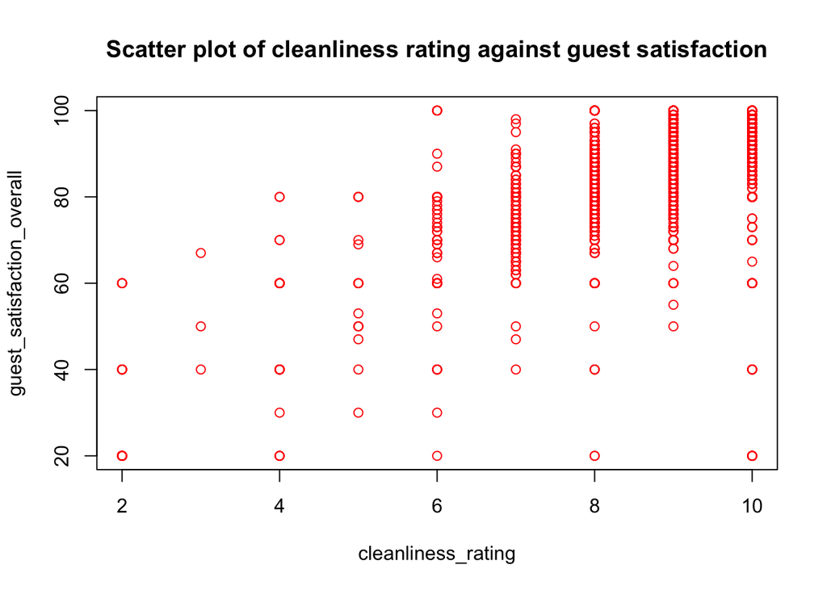

```r
plot(guest_satisfaction_overall ~ cleanliness_rating, data=london_data, main= 'Scatter plot of cleanliness rating against guest satisfaction', col='red')
```

As we can see, there is definitely an apparent upwards correlation here i.e. a higher cleanliness rating contributes to a higher guest satisfaction overall.

Taking a quick look at the p-values of the variables, the immediate insignificant ones include realSum, person_capacity, dist, attr_index, rest_index and lng, if we are considering the standard significance level of 0.05.

We go ahead and also remove the variables that contain a singularity (p-value of NA), to avoid confusion in our new model. This gives us:

```r
lm.fit2 <- lm(guest_satisfaction_overall~ . -realSum - person_capacity - dist - attr_index - rest_index - lng - room_shared - room_private - attr_index_norm - rest_index_norm, data=london_data)
summary(lm.fit2)
```

```
##
## Call:
## lm(formula = guest_satisfaction_overall ~ . - realSum - person_capacity -
##     dist - attr_index - rest_index - lng - room_shared - room_private -
##     attr_index_norm - rest_index_norm, data = london_data)
##
## Residuals:
##     Min      1Q  Median      3Q     Max
## -77.987  -2.366   0.903   3.161  33.704
##
## Coefficients:
##                         Estimate Std. Error t value Pr(>|t|)
## (Intercept)           -490.59064  173.96234  -2.820 0.004819 **
## room_typePrivate room    1.25453    0.20932   5.993 2.19e-09 ***
## room_typeShared room     0.21134    1.40226   0.151 0.880208
## host_is_superhostTrue    1.33420    0.27629   4.829 1.41e-06 ***
## multi                   -1.00801    0.25039  -4.026 5.76e-05 ***
## biz                     -3.79683    0.24438 -15.537  < 2e-16 ***
## cleanliness_rating       6.92055    0.08935  77.458  < 2e-16 ***
## bedrooms                 0.62480    0.17574   3.555 0.000381 ***
## metro_dist               0.17066    0.08770   1.946 0.051715 .
## lat                     10.05247    3.37654   2.977 0.002922 **
## ---
## Signif. codes:  0 '***' 0.001 '**' 0.01 '*' 0.05 '.' 0.1 ' ' 1
##
## Residual standard error: 7.231 on 5369 degrees of freedom
## Multiple R-squared:  0.5904, Adjusted R-squared:  0.5897
## F-statistic: 859.9 on 9 and 5369 DF,  p-value: < 2.2e-16
```

By looking at the R^2 statistics and the RSE, we find those two models are quite similar as they have R^2 = 0.5908 and R^2 = 0.5904. At the same time, the RSEs for two model are 7.232 and 7.231 respectively. We do notice a bit of a decrease with R^2 from the first model to the second, but it is a negligible difference and in both cases, around 59% of the model can explain the dependent variable. We also notice a higher F-statistic in the second model, suggesting a more significant model due to greater differences between population averages. Concluding, these statistics show that the two models are doing decent job in predicting overall guest satisfaction.

```r
df <- read.csv("london_weekends.csv")
df$host_is_superhost <- as.integer(as.logical(df$host_is_superhost))
df$room_shared <- as.integer(as.logical(df$room_shared))
df$room_private <- as.integer(as.logical(df$room_private))
head(df)
```

|  | X | realSum | room_type | room_shared | room_private | person_capacity | host_is_superhost | multi | biz | cleanliness_rating | guest_satisfaction_overall | bedrooms | dist | metro_dist | attr_index | attr_index_norm | rest_index | rest_index_norm | lng | lat |
| --- | --- | --- | --- | --- | --- | --- | --- | --- | --- | --- | --- | --- | --- | --- | --- | --- | --- | --- | --- | --- |
| 1 | 0 | 121.1223 | Private room | 0 | 1 | 2 | 0 | 0 | 0 | 6 | 69 | 1 | 5.734117 | 0.4370940 | 222.8822 | 15.49341 | 470.0885 | 8.413765 | -0.04975 | 51.52570 |
| 2 | 1 | 195.9124 | Private room | 0 | 1 | 2 | 0 | 1 | 0 | 10 | 96 | 1 | 4.788905 | 1.4640505 | 235.3858 | 16.36259 | 530.1335 | 9.488466 | -0.08475 | 51.54210 |
| 3 | 2 | 193.3253 | Private room | 0 | 1 | 3 | 0 | 1 | 0 | 10 | 95 | 1 | 4.596677 | 0.4503062 | 268.9138 | 18.69325 | 548.9876 | 9.825922 | -0.14585 | 51.54802 |
| 4 | 3 | 180.3899 | Private room | 0 | 1 | 2 | 0 | 1 | 0 | 9 | 87 | 1 | 2.054769 | 0.1326705 | 472.3813 | 32.83707 | 1021.2711 | 18.278973 | -0.10611 | 51.52108 |
| 5 | 4 | 405.7010 | Entire home/apt | 0 | 0 | 3 | 0 | 0 | 1 | 7 | 65 | 0 | 4.491277 | 0.3541075 | 318.4915 | 22.13958 | 692.7754 | 12.399473 | -0.18797 | 51.49399 |
| 6 | 5 | 354.1946 | Entire home/apt | 0 | 0 | 2 | 0 | 0 | 1 | 9 | 93 | 0 | 4.467894 | 0.3507494 | 321.8646 | 22.37406 | 703.0686 | 12.583702 | -0.18805 | 51.49473 |

For the initial data preparation, we converted the true and false variables into 0 and 1 to ensure we can logisitcally regress on these variables if need be. The remaining dataset is left untouched.

```r
set.seed(121)
full_model <- glm(data = df, guest_satisfaction_overall ~ .)
null_model <- glm(data = df, guest_satisfaction_overall ~ 1)
summary(full_model)
```

```
##
## Call:
## glm(formula = guest_satisfaction_overall ~ ., data = df)
##
## Deviance Residuals:
##     Min       1Q   Median       3Q      Max
## -77.900   -2.353    0.897    3.208   34.094
##
## Coefficients: (4 not defined because of singularities)
##                         Estimate Std. Error t value Pr(>|t|)
## (Intercept)           -4.888e+02  1.951e+02  -2.506  0.01224 *
## X                     -5.837e-05  6.432e-05  -0.908  0.36418
## realSum                3.253e-04  2.615e-04   1.244  0.21367
## room_typePrivate room  1.489e+00  2.521e-01   5.909 3.66e-09 ***
## room_typeShared room   4.032e-01  1.407e+00   0.287  0.77438
## room_shared                   NA         NA      NA       NA
## room_private                  NA         NA      NA       NA
## person_capacity        1.103e-01  1.187e-01   0.929  0.35296
## host_is_superhost      1.327e+00  2.766e-01   4.797 1.65e-06 ***
## multi                 -1.058e+00  2.526e-01  -4.187 2.87e-05 ***
## biz                   -3.911e+00  2.558e-01 -15.290  < 2e-16 ***
## cleanliness_rating     6.919e+00  8.965e-02  77.181  < 2e-16 ***
## bedrooms               4.467e-01  2.218e-01   2.014  0.04408 *
## dist                  -4.818e-02  8.235e-02  -0.585  0.55851
## metro_dist             2.770e-01  1.290e-01   2.147  0.03187 *
## attr_index            -5.355e-04  1.620e-03  -0.330  0.74105
## attr_index_norm               NA         NA      NA       NA
## rest_index             3.489e-04  6.124e-04   0.570  0.56895
## rest_index_norm               NA         NA      NA       NA
## lng                   -7.215e-01  1.962e+00  -0.368  0.71313
## lat                    1.002e+01  3.782e+00   2.648  0.00811 **
## ---
## Signif. codes:  0 '***' 0.001 '**' 0.01 '*' 0.05 '.' 0.1 ' ' 1
##
## (Dispersion parameter for gaussian family taken to be 52.30437)
##
##     Null deviance: 685485  on 5378  degrees of freedom
## Residual deviance: 280456  on 5362  degrees of freedom
## AIC: 36569
##
## Number of Fisher Scoring iterations: 2
```

```r
set.seed(121)
summary(stepAIC(null_model, # start with a model containing no variables
                direction = 'forward', # run forward selection
                scope = list(upper = full_model, # the maximum to consider is a model with all variables
                             lower = null_model), # the minimum to consider is a model with no variables
                trace = 0))
```

```
##
## Call:
## glm(formula = guest_satisfaction_overall ~ cleanliness_rating +
##     biz + room_private + host_is_superhost + multi + bedrooms +
##     lat + metro_dist + realSum, data = df)
##
## Deviance Residuals:
##     Min       1Q   Median       3Q      Max
## -78.001   -2.363    0.879    3.171   33.800
##
## Coefficients:
##                      Estimate Std. Error t value Pr(>|t|)
## (Intercept)        -4.925e+02  1.739e+02  -2.832  0.00464 **
## cleanliness_rating  6.916e+00  8.936e-02  77.393  < 2e-16 ***
## biz                -3.818e+00  2.446e-01 -15.607  < 2e-16 ***
## room_private        1.347e+00  2.173e-01   6.197 6.17e-10 ***
## host_is_superhost   1.333e+00  2.762e-01   4.825 1.44e-06 ***
## multi              -1.015e+00  2.504e-01  -4.054 5.10e-05 ***
## bedrooms            5.399e-01  1.838e-01   2.937  0.00333 **
## lat                 1.009e+01  3.376e+00   2.989  0.00281 **
## metro_dist          1.885e-01  8.834e-02   2.134  0.03292 *
## realSum             3.929e-04  2.544e-04   1.544  0.12257
## ---
## Signif. codes:  0 '***' 0.001 '**' 0.01 '*' 0.05 '.' 0.1 ' ' 1
##
## (Dispersion parameter for gaussian family taken to be 52.27056)
##
##     Null deviance: 685485  on 5378  degrees of freedom
## Residual deviance: 280641  on 5369  degrees of freedom
## AIC: 36559
##
## Number of Fisher Scoring iterations: 2
```

Upon running forward selection, we can see that most variables are statistically significant at a 0.01 level except for metro_dist and realSum. The AIC is reasonably high at 36559 but still lower than the final model chosen from backward selection (which we will see later). It took 2 iterations to fit the optimal model. But the final model that we get is -

```r
set.seed(121)
summary(stepAIC(full_model, # start with a model containing no variables
                direction = 'backward', # run forward selection
                scope = list(upper = full_model, # the maximum to consider is a model with all variables
                             lower = null_model), # the minimum to consider is a model with no variables
                trace = 0))
```

```
##
## Call:
## glm(formula = guest_satisfaction_overall ~ realSum + room_type +
##     host_is_superhost + multi + biz + cleanliness_rating + bedrooms +
##     metro_dist + lat, data = df)
##
## Deviance Residuals:
##     Min       1Q   Median       3Q      Max
## -77.999   -2.361    0.882    3.167   33.803
##
## Coefficients:
##                         Estimate Std. Error t value Pr(>|t|)
## (Intercept)           -4.930e+02  1.739e+02  -2.834  0.00461 **
## realSum                3.957e-04  2.548e-04   1.553  0.12046
## room_typePrivate room  1.352e+00  2.184e-01   6.188 6.55e-10 ***
## room_typeShared room   3.146e-01  1.404e+00   0.224  0.82266
## host_is_superhost      1.333e+00  2.763e-01   4.824 1.45e-06 ***
## multi                 -1.015e+00  2.504e-01  -4.053 5.12e-05 ***
## biz                   -3.817e+00  2.447e-01 -15.600  < 2e-16 ***
## cleanliness_rating     6.916e+00  8.938e-02  77.385  < 2e-16 ***
## bedrooms               5.408e-01  1.839e-01   2.941  0.00328 **
## metro_dist             1.879e-01  8.839e-02   2.126  0.03357 *
## lat                    1.010e+01  3.376e+00   2.991  0.00280 **
## ---
## Signif. codes:  0 '***' 0.001 '**' 0.01 '*' 0.05 '.' 0.1 ' ' 1
##
## (Dispersion parameter for gaussian family taken to be 52.27981)
##
##     Null deviance: 685485  on 5378  degrees of freedom
## Residual deviance: 280638  on 5368  degrees of freedom
## AIC: 36561
##
## Number of Fisher Scoring iterations: 2
```

Upon running backward selection, we can see that most variables are statistically significant at a 0.01 level except for metro_dist, realSum and room_typeShared room. The AIC is reasonably high at 36561 which is higher than the final model chosen from forward selection. It took 2 iterations to fit the optimal model. But the final model that we get is -

```r
set.seed(121)
# Define training control
df$host_is_superhost <- as.factor(df$guest_satisfaction_overall)
train.control <- trainControl(method = "LOOCV")
# Train the model
model_loocv <- train( guest_satisfaction_overall ~ cleanliness_rating +
    biz + room_private + host_is_superhost + multi + bedrooms +
    lat + metro_dist + realSum, data = df, method = "glm",
               trControl = train.control)
# Summarize the results
print(model_loocv)
```

```
## Generalized Linear Model
##
## 5379 samples
##    9 predictor
##
## No pre-processing
## Resampling: Leave-One-Out Cross-Validation
## Summary of sample sizes: 5378, 5378, 5378, 5378, 5378, 5378, ...
## Resampling results:
##
##   RMSE       Rsquared   MAE
##   0.7350164  0.9958233  0.01412902
```

Upon doing LOOCV (Leave one-out cross validation), we can see that we get a very high r-squared value of 0.9958233. However, the final fit is not ideal as we have a higher RMSE of 0.735 (optimally this value should be lower). However a reall low MAE value of 0.014 shows us that we have an accurate model.

```r
set.seed(121)
# Define training control

rsq_vals <- 0
for (i in 2:10) {
  train.control <- trainControl(method = "cv", number = i)
  # Train the model
  model_kfold <- train(guest_satisfaction_overall ~ cleanliness_rating +
    biz + room_private + host_is_superhost + multi + bedrooms +
    lat + metro_dist + realSum, data = df, method = "glm",
               trControl = train.control)
  print(model_kfold)
  rsq_vals[i] <- model_kfold$results$Rsquared
}
```

```
## Generalized Linear Model
##
## 5379 samples
##    9 predictor
##
## No pre-processing
## Resampling: Cross-Validated (2 fold)
## Summary of sample sizes: 2690, 2689
## Resampling results:
##
##   RMSE      Rsquared   MAE
##   1.729848  0.9774024  0.07157903
##
## Generalized Linear Model
##
## 5379 samples
##    9 predictor
##
## No pre-processing
## Resampling: Cross-Validated (3 fold)
## Summary of sample sizes: 3586, 3585, 3587
## Resampling results:
##
##   RMSE      Rsquared   MAE
##   1.333437  0.9856284  0.0460959
##
## Generalized Linear Model
##
## 5379 samples
##    9 predictor
##
## No pre-processing
## Resampling: Cross-Validated (4 fold)
## Summary of sample sizes: 4034, 4034, 4034, 4035
## Resampling results:
##
##   RMSE       Rsquared   MAE
##   0.9663199  0.9865522  0.04611934
##
## Generalized Linear Model
```

[output cut: 61 more lines]

```
##   RMSE       Rsquared   MAE
##   0.3740741  0.9942165  0.03047194
##
## Generalized Linear Model
##
## 5379 samples
##    9 predictor
##
## No pre-processing
## Resampling: Cross-Validated (10 fold)
## Summary of sample sizes: 4841, 4842, 4842, 4840, 4841, 4841, ...
## Resampling results:
##
##   RMSE       Rsquared   MAE
##   0.5963462  0.9909044  0.03052792
```

```r
# Summarize the results
print(rsq_vals)
```

```
##  [1] 0.0000000 0.9774024 0.9856284 0.9865522 0.9903654 0.9825347 0.9963390
##  [8] 0.9959767 0.9942165 0.9909044
```

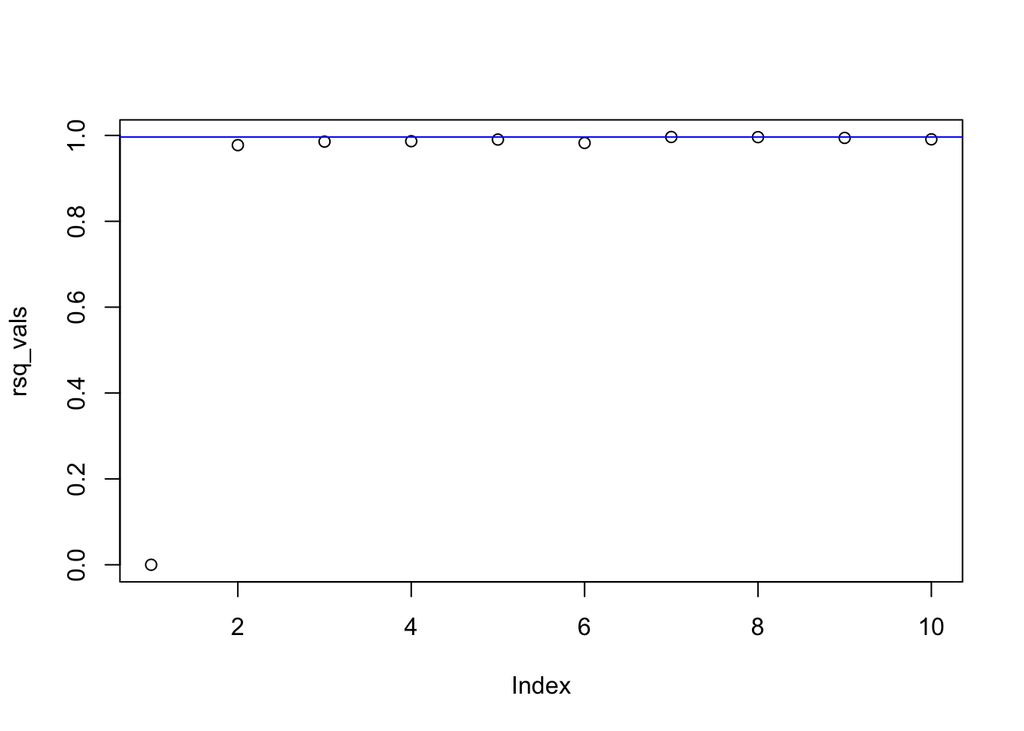

```r
plot(rsq_vals)
abline(h=max(rsq_vals), col="blue")
```

We conducted a k-fold cross validation using k values between 2 and 10. upon comparing the r-squared values of the models at different k, we can see that the one with the highest r-squared value was when k=7 with a value of 0.9963390.

```r
set.seed(121)
data = read.csv("london_weekends.csv")

train = sample(1:nrow(data), nrow(data) / 2)
data.train = data[train, ]
data.test = data[-train, ]
```

In order to build a decision tree to find out what variables most affect the guest satisfaction score, we first split our data set into a training and testing set so that we can build a tree and then confirm its accuracy.

```r
data.tree = tree(guest_satisfaction_overall ~ ., data = data.train)
summary(data.tree)
```

```
##
## Regression tree:
## tree(formula = guest_satisfaction_overall ~ ., data = data.train)
## Variables actually used in tree construction:
## [1] "cleanliness_rating" "biz"
## Number of terminal nodes:  6
## Residual mean deviance:  49.84 = 133700 / 2683
## Distribution of residuals:
##     Min.  1st Qu.   Median     Mean  3rd Qu.     Max.
## -73.7600  -2.4300   0.6551   0.0000   2.5700  27.3500
```

```r
data.tree
```

```
## node), split, n, deviance, yval
##       * denotes terminal node
##
##  1) root 2689 316600 91.19
##    2) cleanliness_rating < 8.5 499 105900 77.57
##      4) cleanliness_rating < 4.5 30   9077 42.90 *
##      5) cleanliness_rating > 4.5 469  58500 79.78
##       10) cleanliness_rating < 7.5 124  16860 72.65 *
##       11) cleanliness_rating > 7.5 345  33070 82.34 *
##    3) cleanliness_rating > 8.5 2190  96870 94.30
##      6) cleanliness_rating < 9.5 814  26740 90.49 *
##      7) cleanliness_rating > 9.5 1376  51360 96.55
##       14) biz < 0.5 1045  15440 97.43 *
##       15) biz > 0.5 331  32550 93.76 *
```

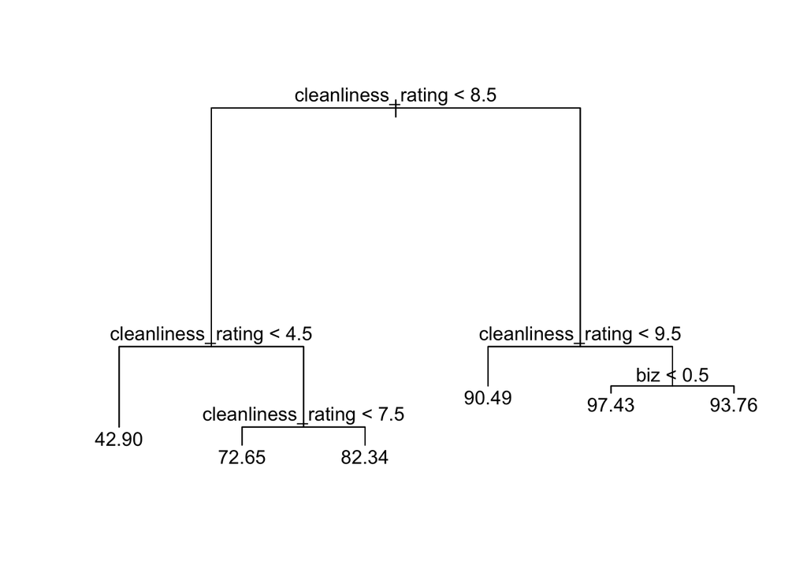

```r
plot(data.tree)
text(data.tree, pretty = 0)
```

Upon building the tree using the tree package, we see that the only variables that are necessary are cleanliness_rating(How clean the listing is on a scale of 1-10) and biz(Whether the listing is for business purposes or not).

```r
data.pred = predict(data.tree, data.test)
mean((data.pred - data$guest_satisfaction_overall)^2)
```

```
## [1] 198.5221
```

After using the other half of the data set to test the accuracy of the tree, we see that the test MSE is really high. This is likely due to overfitting or poor variable selection. In order to test if the tree was overfit, we can prune it using cross-validation.

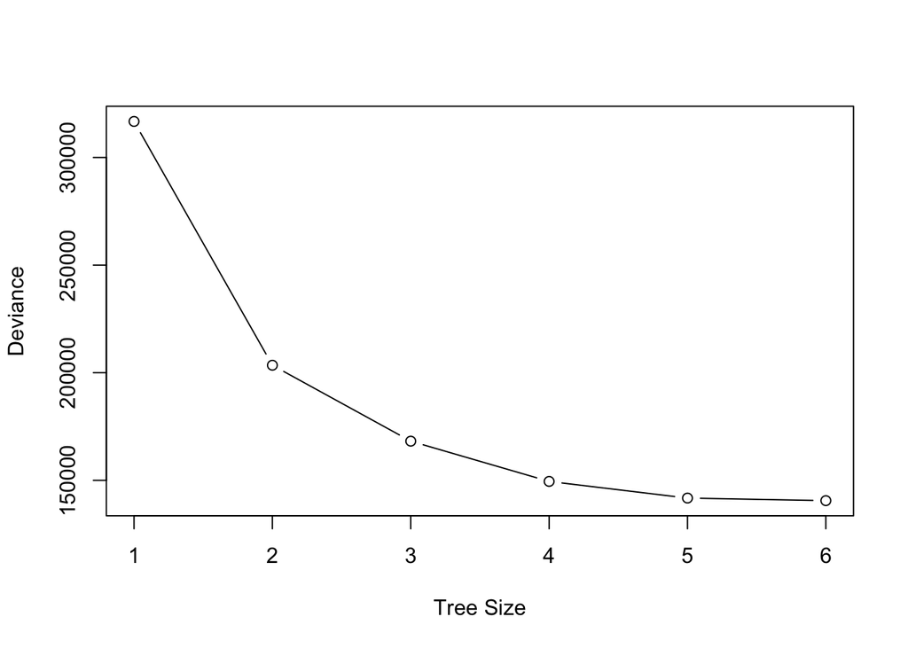

```r
suppressWarnings({
cv.data = cv.tree(data.tree, FUN = prune.tree)
plot(cv.data$size, cv.data$dev, type = "b", xlab = "Tree Size", ylab = "Deviance")
})
```

```r
data.prune = prune.tree(data.tree, best = 5)
prune.pred = predict(data.prune, data.test)
mean((prune.pred - data$guest_satisfaction_overall)^2)
```

```
## [1] 197.7744
```

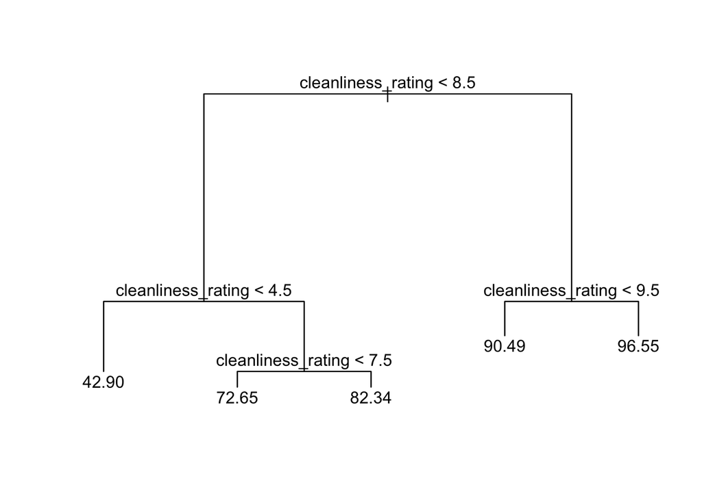

```r
plot(data.prune)
text(data.prune, pretty = 0)
```

Since pruning the tree did not change much from the original tree, as well as the test MSE staying similar, the next step would be to use random forest to create a better predictor.

```r
data.train = as.data.frame(data.train)

randomforest = randomForest(guest_satisfaction_overall ~ ., data = data.train,
                            mtry = ncol(data.train) - 1, importance = TRUE)

forest.pred = predict(randomforest, data.test)
mean((forest.pred - data.test$guest_satisfaction_overall)^2)
```

```
## [1] 60.96958
```

```r
importance(randomforest) |>
  as.data.frame() |>
  rownames_to_column("varname") |>
  arrange(desc(IncNodePurity))
```

| varname | %IncMSE | IncNodePurity |
| --- | --- | --- |
| cleanliness_rating | 141.833519 | 182181.68815 |
| realSum | 17.975469 | 18723.72918 |
| metro_dist | 14.254631 | 16871.28028 |
| X | 2.494126 | 14801.80479 |
| lng | 12.618633 | 14258.76008 |
| lat | 14.837924 | 13751.13776 |
| biz | 25.869730 | 8664.83686 |
| dist | 17.065338 | 8279.56941 |
| attr_index | 12.521444 | 4762.40861 |
| attr_index_norm | 10.858948 | 4631.17475 |

[output cut: 9 more lines]

The random forest has a much lower test MSE, and the most important variables changed from cleanliness_rating and biz to cleanliness_rating, realSum, and metro_dist.

# **Interpretation**